# L’utilisation de nouvelles sources de données pour la statistique publique

Nicolas TOULEMONDE (Insee)

## Sommaire

01

Pourquoi utiliser de nouvelles données ?

02

Données administratives

03

La collecte de données en ligne

04

Données textuelles et non structurées

05

Et encores d’autres données

# 1 Pourquoi utiliser de nouvelles données ?

## 1.1 Les enjeux liés à l’usage de données d’enquête

- Base “historique” des statistiques
- Nombreux avantages : une **finalité** adaptée, un cadre et concept maîtrisés
- Mais ce sont des **données longues à récolter et coûteuses pour le répondant et l’Insee** (plusieurs années)
- Baisse généralisée des taux de réponse aux enquêtes (Luiten et al. 2020; Beck et al. 2022) :
  - Enquête “Cadre de vie et sécurité” : 72 % (2012) à 66 % (2021)
  - SRCV : 85 % (2010) à 80 % (2019)
- Dans un contexte de **demande de statistiques** plus poussées avec des moyens stables

## 1.2 En parallèle, prolifération des données

- Numérisation et innovations technologiques ont réduit le coût de production de la donnée
  - Volume de données produites en explosion
- L’utilisation des statistiques n’est pas nouvelle (cf. [Desrosières](https://www.cairn.info/la-politique-des-grands-nombres--9782707165046.htm))…
- … mais une place accrue :
  - Dans le débat public et l’action publique ([Supiot](https://www.fayard.fr/sciences-humaines/la-gouvernance-par-les-nombres-9782213681092), [Martin](https://www.cairn.info/l-empire-des-chiffres--9782200625719.htm))
  - Dans les stratégies d’entreprise
- Nouvelle législation européenne en 2024 pour permettre l’accès aux données privées - *cf.* [Règlement UE 223/2009](https://eur-lex.europa.eu/legal-content/FR/TXT/?uri=CELEX%3A02009R0223-20241226)

## 1.3 Des nouvelles données disponibles avec de nouvelles méthodes

- Des **données de nature très différentes** :
  - Données administratives, qui sont souvent structurées et classiques
  - Données en ligne (webscraping)
  - Données textuelles et non structurées
  - Et encore d’autres données : images, sons, données localisées
- Besoin de **nouvelles méthodes** pour valoriser ces données :
  - *Machine learning* (re)devenu un outil classique : meilleure prise en compte des non-linéarités, simplicité opérationnelle
  - Réseaux de neurone pour les problèmes complexes (NLP, CV)…
- Cela a des impacts en termes de **compétences** et parfois aussi **d’organisation**

# 2 Données administratives

## 2.1 Que sont les données administratives ?

- **Enregistrements automatisés** de systèmes de gestion
- Produite par une administration, avec **coût marginal d’accès faible** pour l’INS
- Une **nouvelle place pour l’INS** qui exploite le flux, car l’autorité gestionnaire occupe une place centrale.

| Donnée | Autorité centralisatrice |
| --- | --- |
| DSN | Gip-MDS |
| Données hospitalières | ATIH-10 |
| SI gestion des eaux | SANDRE12 |

## 2.2 Exemple 1 : la déclaration sociale nominative (DSN)

- Données issues des fiches de paie (Humbert-Bottin 2018)

[figure not shown]

## 2.3 Exemple 2 : SIRENE

- Répertoire d’entreprises administré par l’Insee :
  - Centralise de l’information sur 32 millions d’établissements
  - Dont 13 millions d’établissements actifs
- Met à disposition des utilisateurs un code APE (pour activité principale exercée)
- Base de référence pour toutes les études et enquêtes statistiques sur les entreprises

# 3 La collecte de données en ligne

## 3.1 Les opportunités et difficultés posées par le webscraping

- **Webscraping** : extraction du contenu de sites Internet
- Information textuelle **très riche** sur Internet, mobilisable à des fins de statistique publique
- **Enjeux** :
  - **Techniques** : évolution des pages web, interactivité des sites
  - **Légaux** : jurisprudences, directives de 2020 de la CNIL
- l’usage de webscraping nécessite un **suivi important en production**. => On privilégie d’autres modes de collecte (API) quand cela est possible

## 3.2 Des exemples d’utilisation de webscraping

- Prix dans le **domaine de l’hôtellerie** : scraping du site [Booking.com](https://www.booking.com/)
- Vente d’**articles électroniques** :
  - [Boulanger](https://www.boulanger.com/)
  - [Rue du commerce](https://www.rueducommerce.fr/)
- Scraping du **site de la SNCF** : collecte quotidienne pour capter la volatilité des prix
- Scrapping des offres d’emploi (projet [**Jocas**](https://dares.travail-emploi.gouv.fr/enquete-source/jocas)) par la Dares

# 4 Données textuelles et non structurées

## 4.1 Pourquoi utiliser des textuelles et non structurées

- Rapports comptables, annonces légales, journal officiel
- Un des **domaines de recherche les plus actifs** en *data science*
  - Collecte accrue : réseaux sociaux, enquêtes, *webscraping*…
  - Baisse coûts stockage & augmentation ressources traitement
  - Nouvelles techniques statistiques : LLM…
- **Beaucoup d’applications** potentielles pour la statistique publique :
  - Données d’**enquête**
  - Données **administratives**
  - Données **privées** mobilisables pour la statistique publique

## 4.2 Un exemple : classifier l’activité principale des entreprises

- Classification dans des **nomenclatures** :
  - **Profession** (enquêtes, recensement de la population)
  - **Activité** des entreprises
  - **Produits** de consommation
- **Appariements**
- **Extraction automatique** de contenu au sein de documents textuels
- Modèles de langage **génératifs** : assistants de code, RAG, etc.
- Classification automatique de l’activité principale d’une entreprise :

[interactive chart not shown]

# 5 Et encores d’autres données

## 5.1 L’utilisation d’images

### Pour quels cas d’usage ?

- Utilisation **d’images satellites** avec des cas d’usage potentiels multiples (supervision des forêts, de l’agriculture, des masses d’eau, supervision de l’urbanisation et des infrastructures, etc)
- Utilité de techniques d’OCR/**reconnaissance optique de caractères** pour les documents scannés ou photographiés :
  - Comptes **annuels des entreprises**
  - **Permis de construire**
  - Photographies de **tickets de caisse** pour l’enquête Budget de Famille

### Quelques exemples - images satellites

- Utilisation d’images satellites :
  - Calcul de statistiques sur **l’occupation et l’usage des sols** (consolidation de l’enquête Teruti)
  - Consolidation des **statistiques sur les vergers** issues de l’enquête sur la structure des exploitations agricoles
  - Mise à jour du **répertoire de logements** dans les DROM

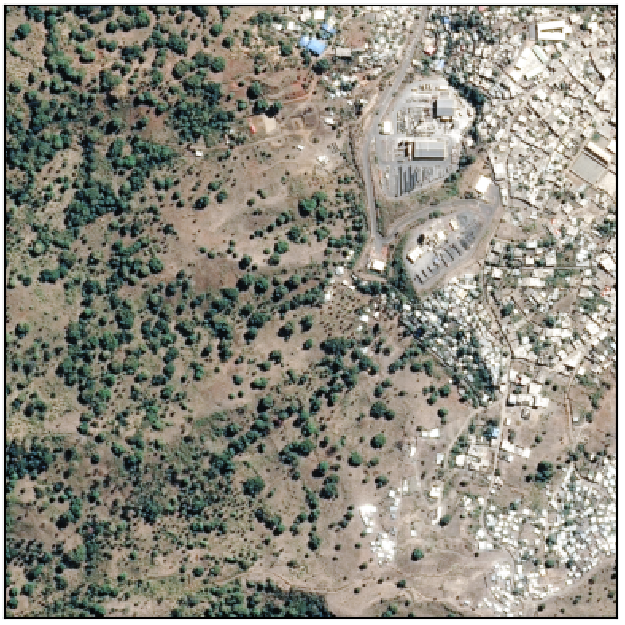

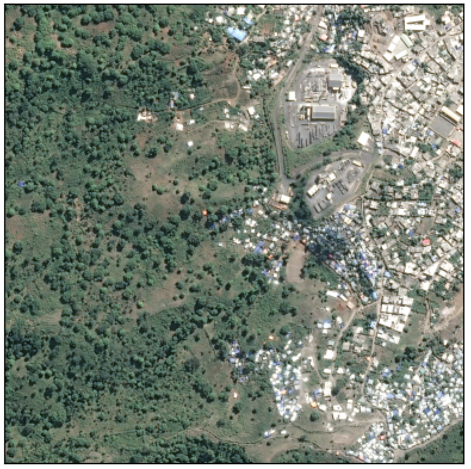

### Quelques exemples - OCR

[figure not shown]

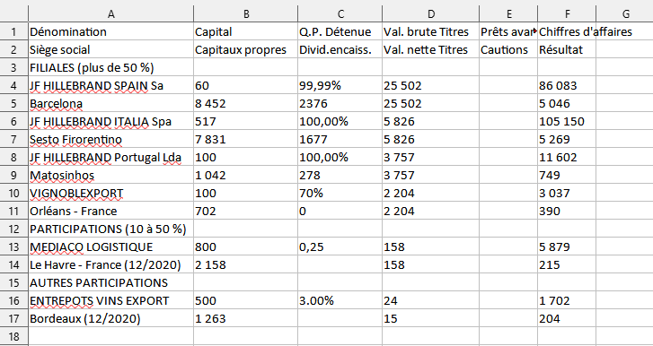

## 5.2 Données géolocalisées

### Pourquoi a-t-on besoin de telles données ?

- Calculer des indicateurs avec une **granularité spatiale fine** pour les acteurs publics et privés
- Éclairer des **phénomènes socio-économiques très locaux** (mixité (Galiana, Sémécurbe, et al. 2020), concentration immobilière (André et Meslin 2021))
- Réaliser des *dataviz* plus engageantes pour le public
- Généralisation de traces numériques géolocalisées :
  - Multiplication des acteurs (production & exploitation)
  - Données mobile, GPS, localisation d’adresses IP, géolocalisation d’adresses…

### Exemple : données de téléphonie mobile

- Statistiques intéressantes sur les populations présentes et les déplacements de la population Galiana, Suarez-Castillo, et al. (2020) : mouvements de population avant/après le confinement de 2020

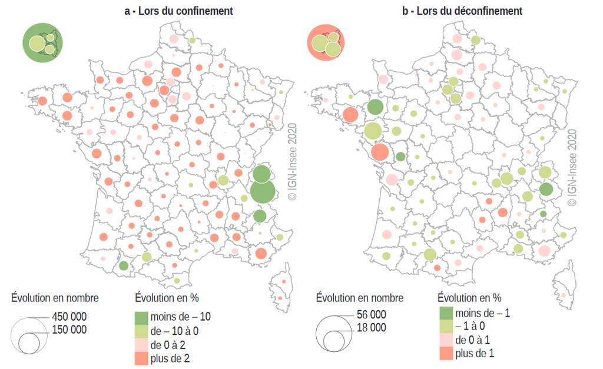

### Autres exemples de données géolocalisées

- `Fideli` (Fichier démographique sur les logements et les individus)
- `Filosofi` (Fichier localisé social et fiscal)
- `BPE` (Base permanente des équipements)
- `Sirene` (répertoire des entreprises)
- `RP` (Recensement de la Population)
- Nicolas TOULEMONDE
- Laboratoire d’innovation en data-science (SSPLab)
- Direction de la méthodologie, de la coordination statistique et internationale (DMCSI)

## Bibliographie

André, Mathias, et Olivier Meslin. 2021. *Et pour quelques appartements de plus : Étude de la propriété immobilière des ménages et du profil redistributif de la taxe foncière*.

Beck, François, Laura Castell, Stéphane Legleye, et Amandine Schreiber. 2022. « Le multimode dans les enquêtes auprès des ménages : une collecte modernisée, un processus complexifié ». *Courrier des statistiques*.

Galiana, Lino, François Sémécurbe, Benjamin Sakarovitch, et Zbigniew Smoreda. 2020. *Residential segregation, daytime segregation and spatial frictions: an analysis from mobile phone data*.

Galiana, Lino, Milena Suarez-Castillo, François Sémécurbe, Élise Coudin, et Marie-Pierre de Bellefon. 2020. *Retour partiel des mouvements de population avec le déconfinement*.

Humbert-Bottin, Élisabeth. 2018. « La déclaration sociale nominative: nouvelle référence pour les échanges de données sociales des entreprises vers les administrations ». *Courrier des statistiques*.

Luiten, Annemieke, Joop Hox, et Edith de Leeuw. 2020. « Survey Nonresponse Trends and Fieldwork Effort in the 21st Century: Results of an International Study across Countries and Surveys ». *Journal of Official Statistics* 36 (3): 469‑87. https://doi.org/doi:10.2478/jos-2020-0025.